# Take-Home Assessment 3

Author

Ben Sunshine

```r
library(tidyverse)
lego_df <- read_csv(here::here("data/lego_sample.csv")) |>
  mutate(minifigures = if_else(is.na(minifigures),
                               true = 0,
                               false = minifigures))
```

Question 1 (1 point). In R, fit the model with pieces and theme as predictors using lm(). Then, provide a summary tibble of output with tidy().

```r
library(broom)
lm_price_1 <- lm(price ~ pieces + theme, data = lego_df)

lm_price_1 %>% tidy()
```

```
# A tibble: 4 × 5
  term         estimate std.error statistic  p.value
  <chr>           <dbl>     <dbl>     <dbl>    <dbl>
1 (Intercept)     5.82     4.22        1.38 1.72e- 1
2 pieces          0.124    0.0102     12.2  4.72e-19
3 themeDUPLO®    16.8      5.09        3.29 1.55e- 3
4 themeFriends  -10.9      4.47       -2.44 1.73e- 2
```

Question 2 (1 point). Interpret the fitted model coefficient for the Friends theme, b3, in context of the problem.

- Holding the number of pieces in the Lego set constant, the model predicts the price of a Lego set to be $10.88 cheaper on average when the theme is “Friends”.

Question 3 (1 point). Using augment(), determine if there are any observations with a cook’s distance value above 0.75, a common cut-off for determining if there are influential points.

```r
augment(lm_price_1) %>%
  filter(.cooksd > 0.75)
```

```
# A tibble: 0 × 9
# ℹ 9 variables: price <dbl>, pieces <dbl>, theme <chr>, .fitted <dbl>,
#   .resid <dbl>, .hat <dbl>, .sigma <dbl>, .cooksd <dbl>, .std.resid <dbl>
```

- There are no obervartions with a cook’s distance value above 0.75.

Question 4 (1 point). Add minifigures, the number of minifigures included in the set, as a predictor to the model that already has pieces and theme. Interpret the fitted model coefficient for minifigures, b4, in context of the problem.

```r
lm_price_mini_figure <- lm(price ~ pieces + theme + minifigures, data = lego_df)

lm_price_mini_figure %>% tidy()
```

```
# A tibble: 5 × 5
  term         estimate std.error statistic  p.value
  <chr>           <dbl>     <dbl>     <dbl>    <dbl>
1 (Intercept)    -3.69     4.60      -0.802 4.25e- 1
2 pieces          0.108    0.0103    10.5   5.80e-16
3 themeDUPLO®    21.8      4.84       4.49  2.71e- 5
4 themeFriends   -3.03     4.58      -0.662 5.10e- 1
5 minifigures     3.73     0.977      3.82  2.89e- 4
```

- Holding the number of pieces and theme of the Lego set constant, the model predicts the price of a Lego set on average to increase by $3.73 for each additional minifigure included in the set.

Question 5 (1 point). What would an interaction between theme and minifigures allow for? Explain what adding an interaction between these two predictors would allow the model to do, to someone with little statistical background. (You do not need to actually add the interaction term).

- Adding an interaction term between the two variables would allow us the association between minifigures and price to be different values depending on theme.

Question 6 (1 point). Suppose that you want to visualize the model with pieces, theme, and minifigures as predictors (with no interactions). Sketch out a visualization that incorporates all 3 predictors and the response in some way. You do not need to turn anything in for this question, but completing this may be good practice for the handwritten quiz.

Question 7 (4 points). Construct the visualization that you sketched out in R. Note that your visualization should show that an interaction term between pieces and theme would improve the model fit: the slope between price and pieces looks like it should be much steeper for the DUPLO theme than the other two themes.

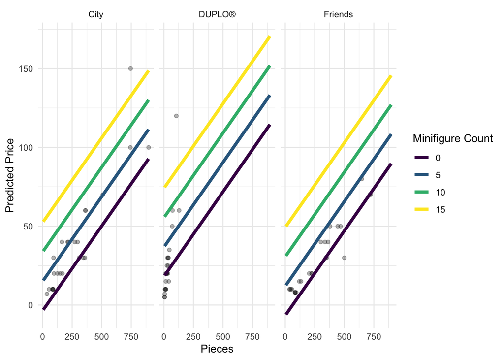

```r
library(modelr)
grid_mini <- lego_df |>
data_grid(
  pieces = seq_range(pieces, n = 10),
  theme = c("City", "DUPLO®", "Friends"),
  minifigures = seq_range(minifigures, n = 4)
  )

aug_mini_figures <- augment(lm_price_mini_figure, newdata = grid_mini, interval = "confidence")


aug_mini_figures %>%
  ggplot(aes(x = pieces,
             y = .fitted,
             group = minifigures)) +
  geom_point(data = lego_df, aes(x = pieces, y = price), alpha = 0.3) +
  geom_line(aes(color = as.factor(minifigures)),
            linewidth = 1.5) +
  scale_color_viridis_d() +
  scale_fill_viridis_d() +
  facet_wrap(~ theme) +
  theme_minimal() +
  labs(color = "Minifigure Count",
       x = "Pieces",
       y = "Predicted Price")
```